# Statistical Learning report

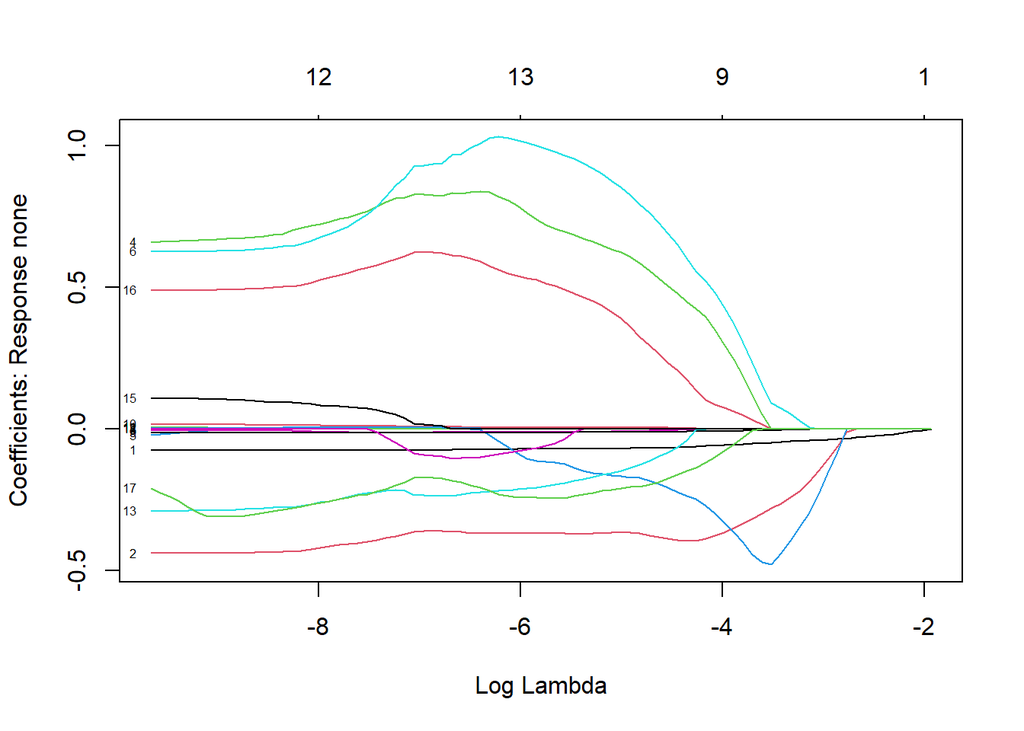

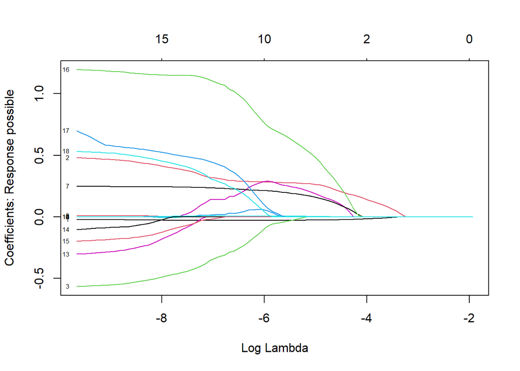

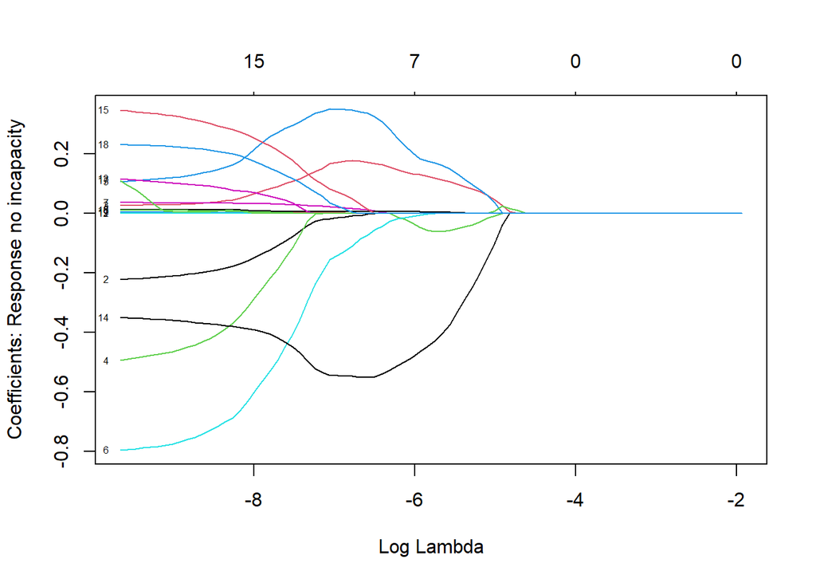

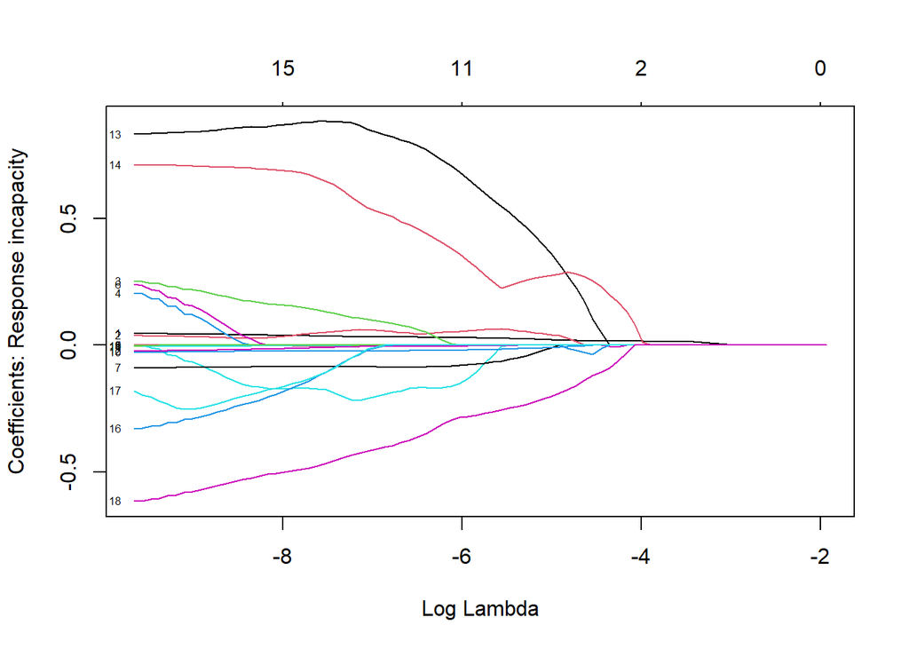

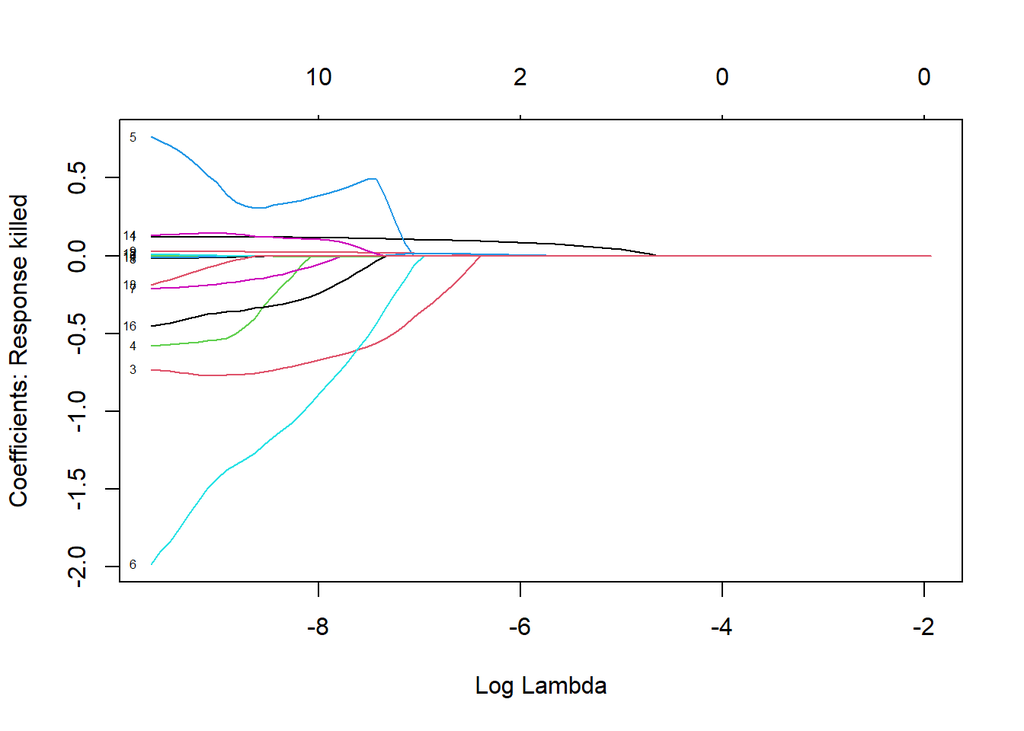

```r
plot(glmnet(train.int.x,train.y,weights=train.data$weight,family='multinomial',lambda=int.lasso.fit$lambda,alpha=1),xvar='lambda',label=TRUE)
```

Let’s test the Lasso model:

```r
preds <- factor(predict(int.lasso.fit,test.int.x,type='class',s='lambda.min'),levels=c('none','possible','no incapacity','incapacity','killed'))
newx<-data.frame(preds=preds,target=test.y,weights=test.data$weight)
conf.mat<-conf_mat(newx,target,preds,case_weights=weights)
print(summary(conf.mat))
```

```
## # A tibble: 13 × 3
##    .metric              .estimator .estimate
##    <chr>                <chr>          <dbl>
##  1 accuracy             multiclass    0.509
##  2 kap                  multiclass    0.103
##  3 sens                 macro         0.248
##  4 spec                 macro         0.819
##  5 ppv                  macro        NA
##  6 npv                  macro         0.854
##  7 mcc                  multiclass    0.135
##  8 j_index              macro         0.0674
##  9 bal_accuracy         macro         0.534
## 10 detection_prevalence macro         0.2
## 11 precision            macro         0.380
## 12 recall               macro         0.248
## 13 f_meas               macro         0.290
```

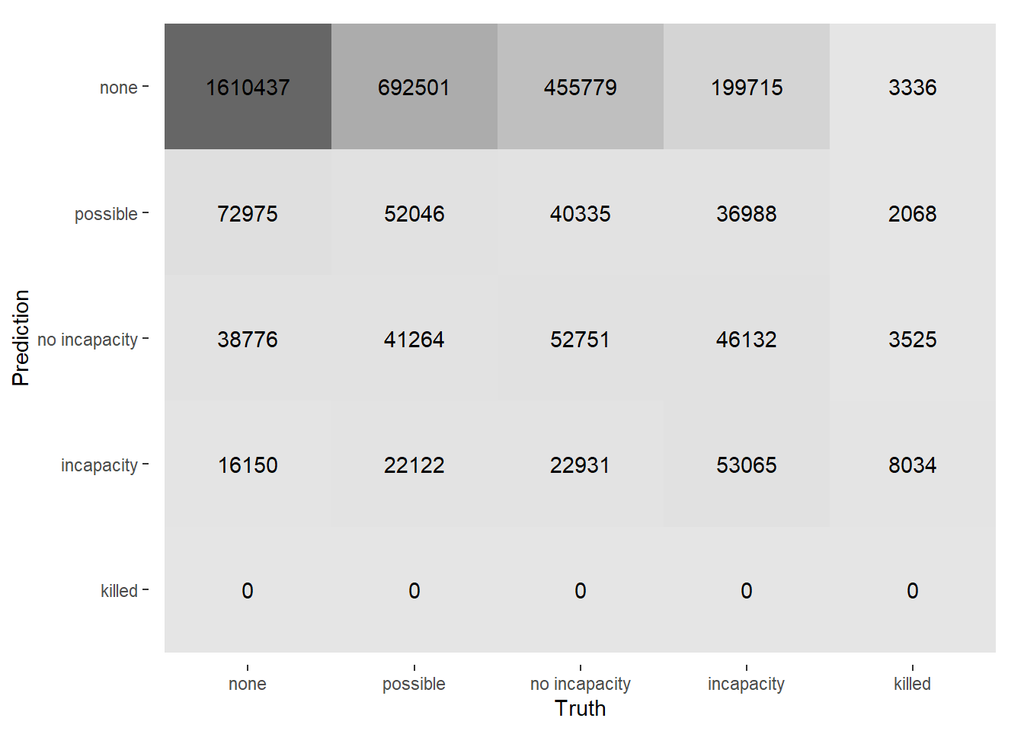

```r
autoplot(conf.mat,type='heatmap')
```

As we can see, lasso regularization makes the model unable to predict death.

#### Interactions + Ridge regression

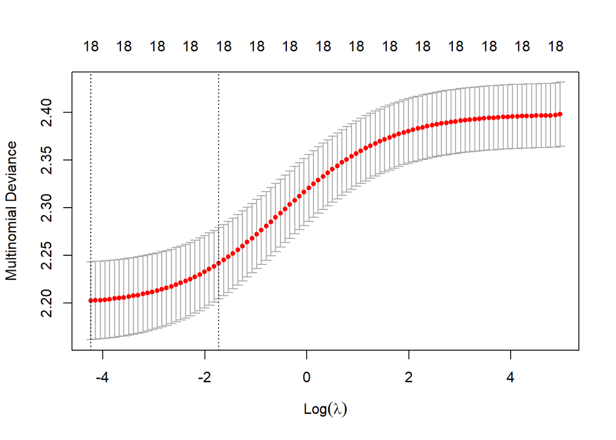

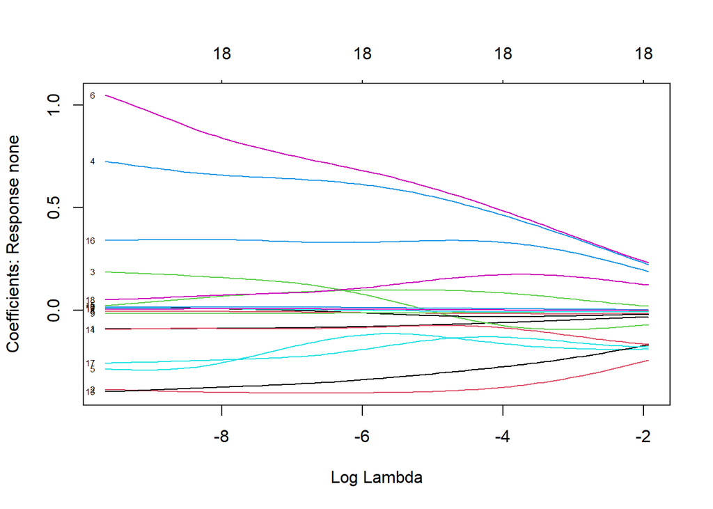

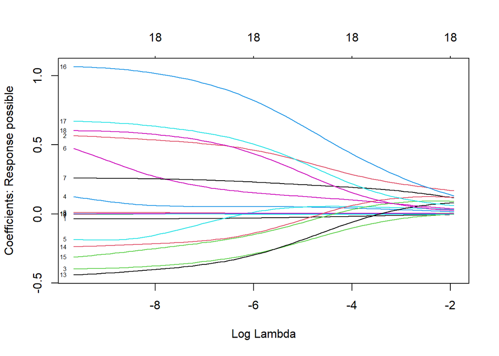

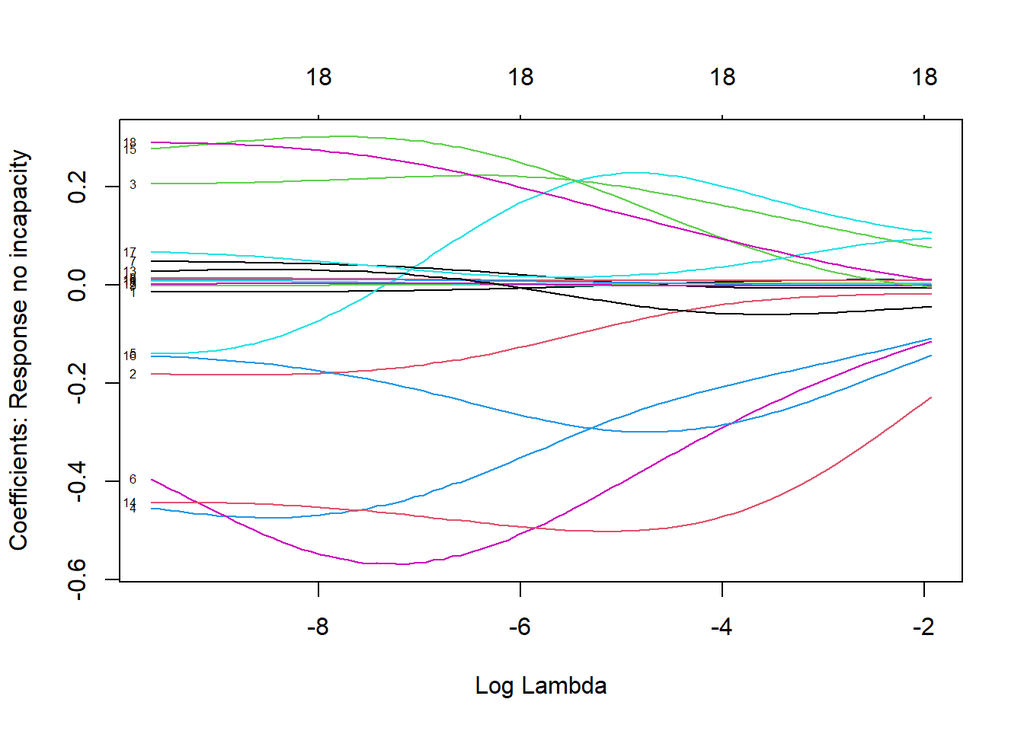

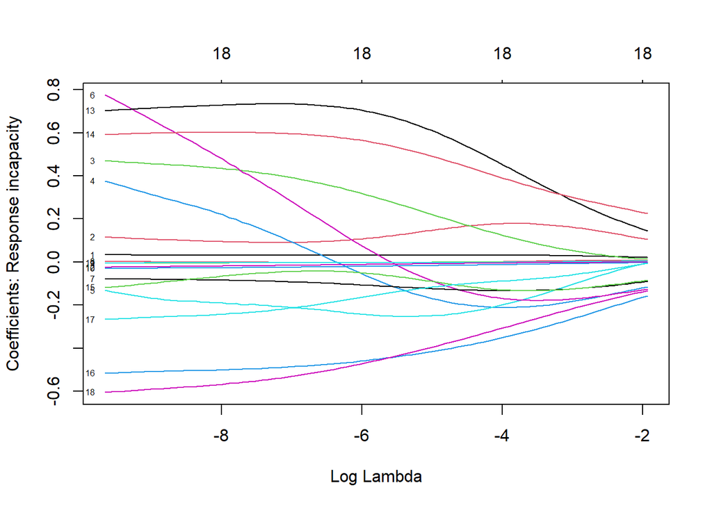

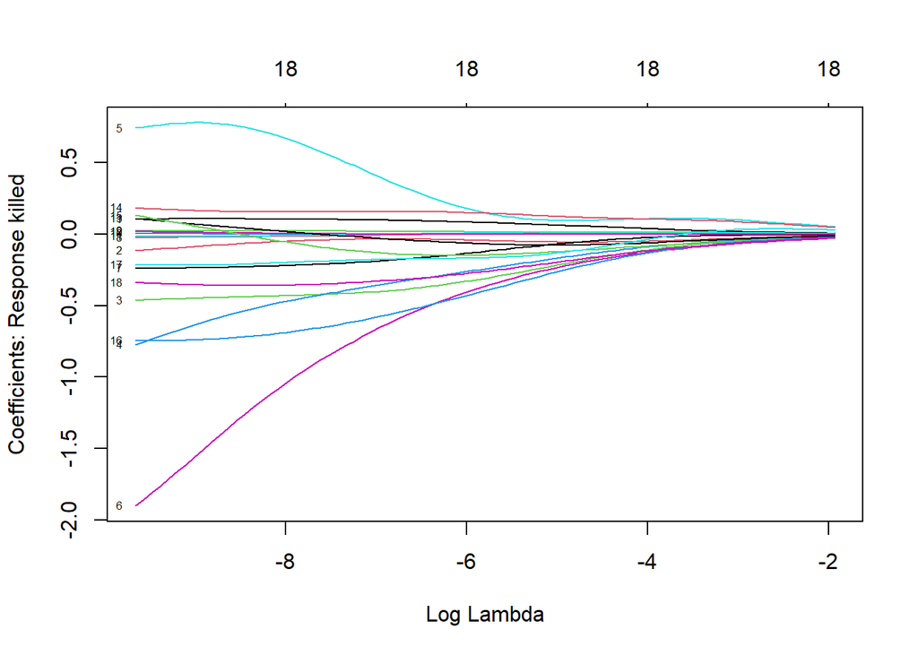

```r
int.ridge.fit<-cv.glmnet(train.int.x,train.y,family='multinomial',weights=train.data$weight,alpha=0)
plot(int.ridge.fit)
```

Let’s test the Ridge model:

```r
preds <- factor(predict(int.ridge.fit,test.int.x,type='class',s='lambda.min'),levels=c('none','possible','no incapacity','incapacity','killed'))
newx<-data.frame(preds=preds,target=test.y,weights=test.data$weight)
conf.mat<-conf_mat(newx,target,preds,case_weights=weights)
print(summary(conf.mat))
```

```
## # A tibble: 13 × 3
##    .metric              .estimator .estimate
##    <chr>                <chr>          <dbl>
##  1 accuracy             multiclass    0.505
##  2 kap                  multiclass    0.0853
##  3 sens                 macro         0.242
##  4 spec                 macro         0.816
##  5 ppv                  macro        NA
##  6 npv                  macro         0.849
##  7 mcc                  multiclass    0.118
##  8 j_index              macro         0.0580
##  9 bal_accuracy         macro         0.529
## 10 detection_prevalence macro         0.2
## 11 precision            macro         0.369
## 12 recall               macro         0.242
## 13 f_meas               macro         0.277
```

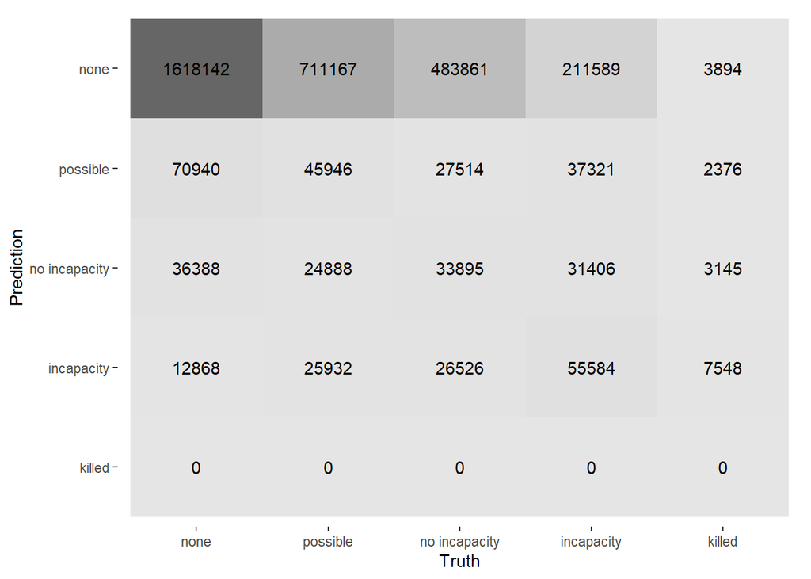

```r
autoplot(conf.mat,type='heatmap')
```

Like Lasso regression, Ridge regression worsens the model performance.

## What do these models tell us?

We look at the full ordered logistic regression model, since it is a good compromise between performance and ease of interpretation.

First we compute the Variance Inflation Factors of its coefficients, to see how much the estimate is reliable.

```r
vif(fullord.m)
```

```
## onlyseatbelt   onlyairbag     beltedab        dvcat          sex     ageOFocc
##     2.511124     1.953813     3.971735     1.054218     1.052545     1.012894
##      occRole      frontal       vehage
##     1.019337     1.030589     2.014412
```

The vif is low, so there is very little collinearity and the coefficients are reliable.

Now let’s take a look at the model summary:

```r
summary(fullord.m)
```

```
## Call:
## polr(formula = injSevFactor ~ onlyseatbelt + onlyairbag + beltedab +
##     dvcat + sex + ageOFocc + occRole + frontal + vehage, data = train.data,
##     weights = weight, start = c(m$coefficients, m$zeta), Hess = TRUE)
##
## Coefficients:
##                 Value Std. Error  t value
## onlyseatbelt -1.12252  2.287e-03 -490.877
## onlyairbag    0.08252  3.328e-03   24.795
## beltedab     -1.09940  2.725e-03 -403.420
## dvcat         0.06666  7.298e-05  913.356
## sex           0.55372  1.390e-03  398.459
## ageOFocc      0.01152  3.892e-05  296.054
## occRole       0.01469  1.765e-03    8.321
## frontal      -0.07586  1.423e-03  -53.320
## vehage        0.01168  1.858e-04   62.852
##
## Intercepts:
##                          Value     Std. Error t value
## none|possible               1.3657    0.0040   339.5997
## possible|no incapacity      2.5658    0.0041   626.9981
## no incapacity|incapacity    3.7476    0.0042   889.7450
## incapacity|killed           7.1247    0.0065  1091.1897
##
## Residual Deviance: 18701759.69
## AIC: 18701785.69
```

Finally, to interpret the coefficients, we exponentiate them:

```r
exp(fullord.m$coefficients)
```

```
## onlyseatbelt   onlyairbag     beltedab        dvcat          sex     ageOFocc
##    0.3254592    1.0860225    0.3330704    1.0689329    1.7397103    1.0115903
##      occRole      frontal       vehage
##    1.0147949    0.9269428    1.0117454
```

These numbers represent the multiplicative increase in the odds of an incident resulting in a worse injury.

To try and simplify the problem, we turn injury severity into a binary variable, with value 1 in cases of ‘incapacity’ or ‘killed’ and zero otherwise.

Since models only seem to gain around 3% accuracy compared to the null model, we tried simpifying the problem: instead of predicting the level of injury, we define a binary variable with value 1 in cases of incapacity or death, and 0 otherwise.

```r
pdata$severe<-as.numeric(pdata$injSeverity>=3)
```

## Modeling the severe variable

This is now a binary classification problem.

### Useful functions

#### Accuracy

```r
acc.log<-function(m,data){
  target<-data$severe
  pred<-predict(m,newdata=data, type="response") > 0.5
  success<-data[target==pred,]
  sum(success$weight)/sum(data$weight)
}
```

#### Draw ROC curve and get AUC

```r
roc.auc<-function(m,data,make.plot=FALSE){
  target<-data$severe
  pred<-predict(m,newdata=data, type="response")
  weights<-data$weight
  my.roc<-WeightedROC(pred,target,weights)
  print(WeightedAUC(my.roc))
  if (make.plot==TRUE){
    gg<-ggplot()+geom_path(aes(FPR,TPR),data=my.roc)+coord_equal()
    gg
  }

}
```

### The full model

```r
sample <- sample.split(pdata$weight, SplitRatio = 0.7)
train.data  <- subset(pdata, sample == TRUE)
test.data   <- subset(pdata, sample == FALSE)
```

```r
full.log.m<-glm(severe~dvcat+onlyseatbelt+onlyairbag+beltedab+occRole+frontal+ageOFocc+sex+vehage,data=train.data,family='binomial',weights=weight)

base.log.m <- glm(severe~+1,data=train.data,weights=weight,family='binomial')
summary(full.log.m)
```

```
##
## Call:
## glm(formula = severe ~ dvcat + onlyseatbelt + onlyairbag + beltedab +
##     occRole + frontal + ageOFocc + sex + vehage, family = "binomial",
##     data = train.data, weights = weight)
##
## Deviance Residuals:
##     Min       1Q   Median       3Q      Max
## -155.90    -7.28    -2.76     8.49   411.32
##
## Coefficients:
##                Estimate Std. Error z value Pr(>|z|)
## (Intercept)  -2.984e+00  6.750e-03 -442.06   <2e-16 ***
## dvcat         6.740e-02  1.050e-04  641.84   <2e-16 ***
## onlyseatbelt -1.060e+00  3.564e-03 -297.52   <2e-16 ***
## onlyairbag   -1.887e-01  5.088e-03  -37.09   <2e-16 ***
## beltedab     -1.291e+00  4.442e-03 -290.65   <2e-16 ***
## occRole      -1.020e-01  3.091e-03  -33.01   <2e-16 ***
## frontal      -3.433e-01  2.537e-03 -135.28   <2e-16 ***
## ageOFocc      6.224e-03  6.988e-05   89.06   <2e-16 ***
## sex           5.561e-01  2.518e-03  220.80   <2e-16 ***
## vehage       -2.332e-02  3.257e-04  -71.62   <2e-16 ***
## ---
## Signif. codes:  0 '***' 0.001 '**' 0.01 '*' 0.05 '.' 0.1 ' ' 1
##
## (Dispersion parameter for binomial family taken to be 1)
##
##     Null deviance: 5524383  on 18025  degrees of freedom
## Residual deviance: 4832504  on 18016  degrees of freedom
## AIC: 4832524
##
## Number of Fisher Scoring iterations: 8
```

We look at the VIF to search for collinearity between the predictors:

```r
vif(full.log.m)
```

```
##        dvcat onlyseatbelt   onlyairbag     beltedab      occRole      frontal
##     1.076872     1.821663     2.001055     3.092918     1.020654     1.035237
##     ageOFocc          sex       vehage
##     1.009521     1.063863     2.032418
```

The factors are all very low, so the estimates of the coefficients are reliable.

Now we look at the accuracies of the full and base model to evaluate them:

```r
acc.log(full.log.m,test.data)
```

```
## [1] 0.8937216
```

```r
acc.log(base.log.m,test.data)
```

```
## [1] 0.8920794
```

The accuracy of the null model is already 89%! A better way to evaluate how much the model improves on the null model is the AUC.

```
## [1] 0.7432676
```

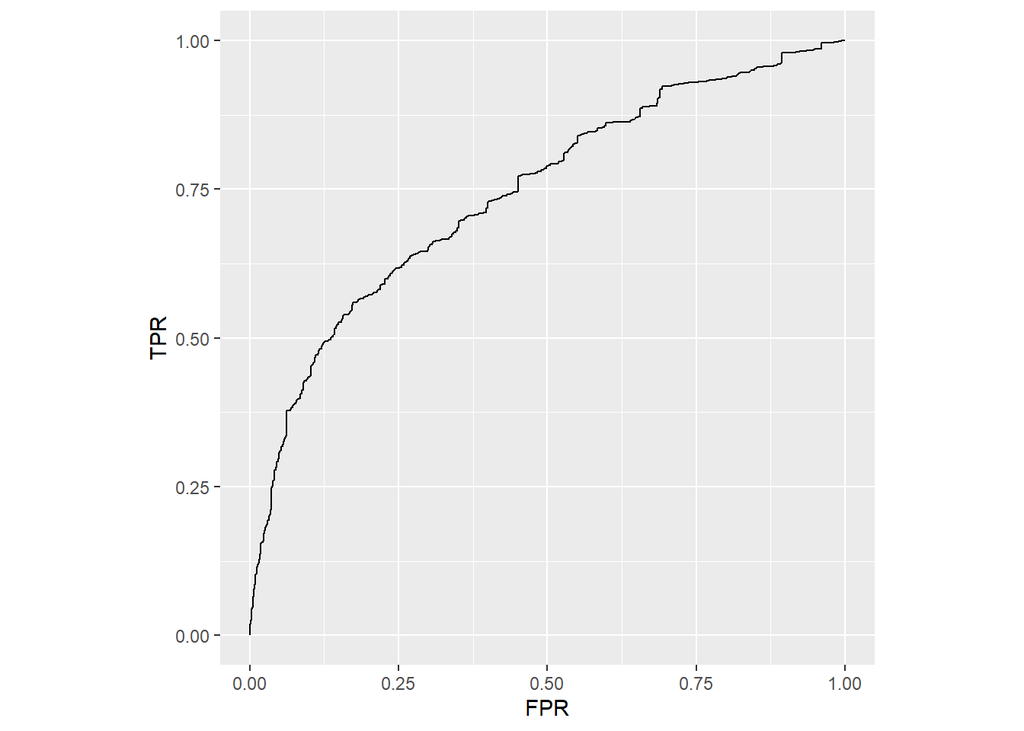

```r
roc.auc(full.log.m,test.data,make.plot=TRUE)
```

### Regularized models

```r
train.x<-as.matrix(subset(train.data,select=-c(weight,dead,airbag,seatbelt,yearacc,yearVeh,deploy,injSeverity,injSevFactor,severe)))
train.y<-train.data$severe
test.x<-as.matrix(subset(test.data,select=-c(weight,dead,airbag,seatbelt,yearacc,yearVeh,deploy,injSeverity,injSevFactor,severe)))
test.y<-test.data$severe
```

#### Ridge regression

We use the cv.glmnet function to select the best $\lambda$ using cross-validation, then test the resulting model on the test set.

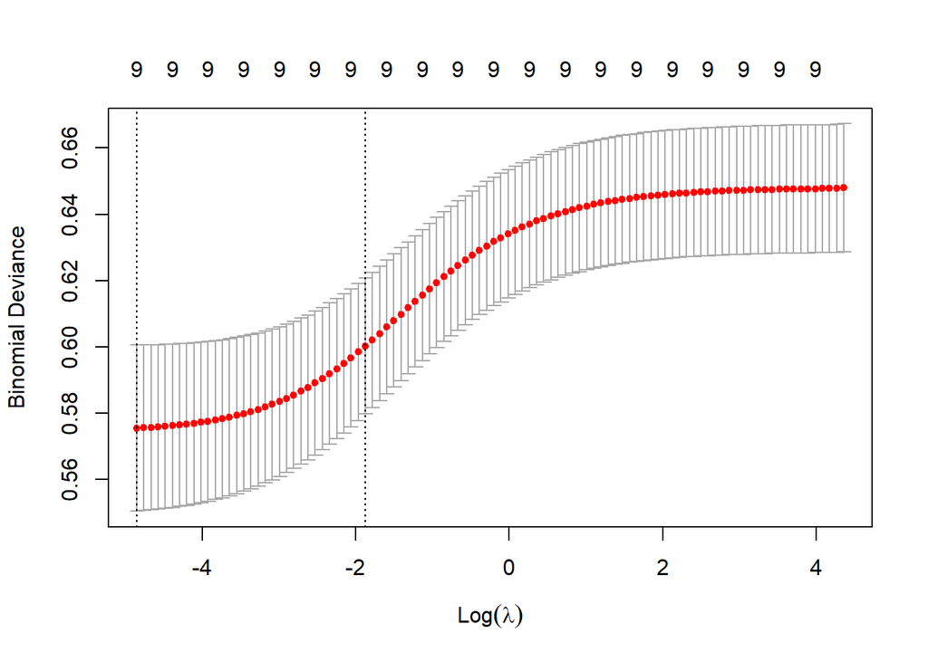

```r
ridge.fit <- cv.glmnet(train.x, train.y, alpha = 0, family='binomial',weights=train.data$weight)
lambdas=ridge.fit$lambda
plot(ridge.fit)
```

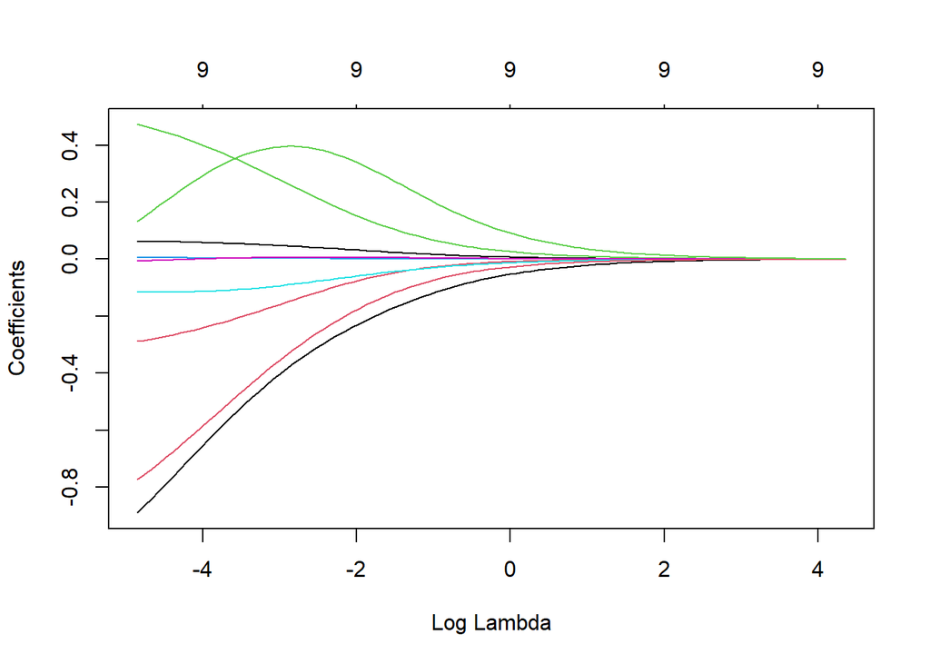

```r
ridge<-glmnet(train.x,train.y,alpha= 0, family='binomial',weights=train.data$weight,lambda=lambdas)
plot(ridge,xvar='lambda')
```

Now let’s test the ridge regression model:

```r
pred<-predict(ridge.fit,test.x,s='lambda.min',type='response')
my.roc<-WeightedROC(pred,test.y,test.data$weight)
WeightedAUC(my.roc)
```

```
## [1] 0.7431653
```

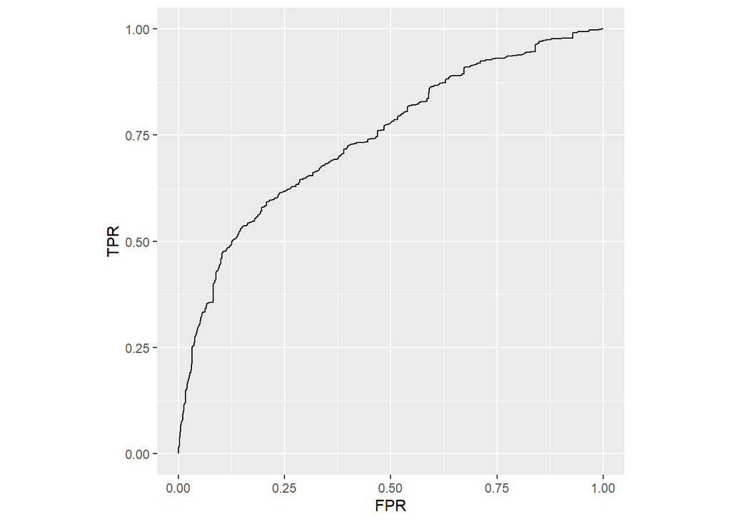

```r
ggplot()+geom_path(aes(FPR,TPR),data=my.roc)+coord_equal()
```

#### Lasso regression

We proceed the same way as for the ridge regression:

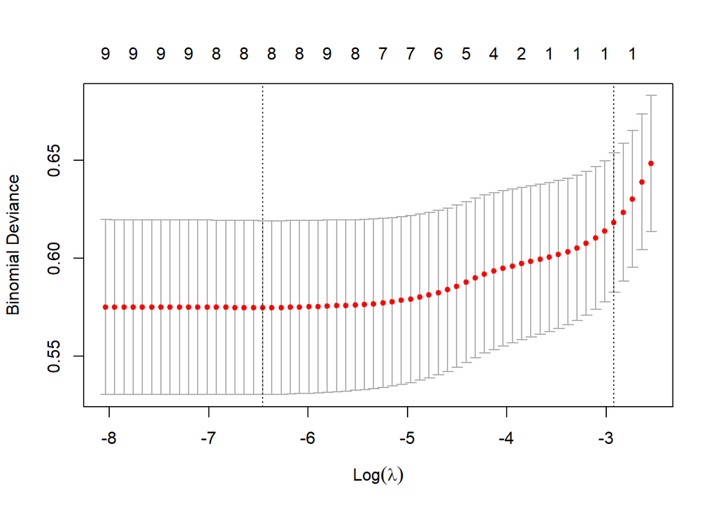

```r
lasso.fit <- cv.glmnet(train.x, train.y, alpha = 1, family='binomial',weights=train.data$weight)
lambdas=lasso.fit$lambda
plot(lasso.fit)
```

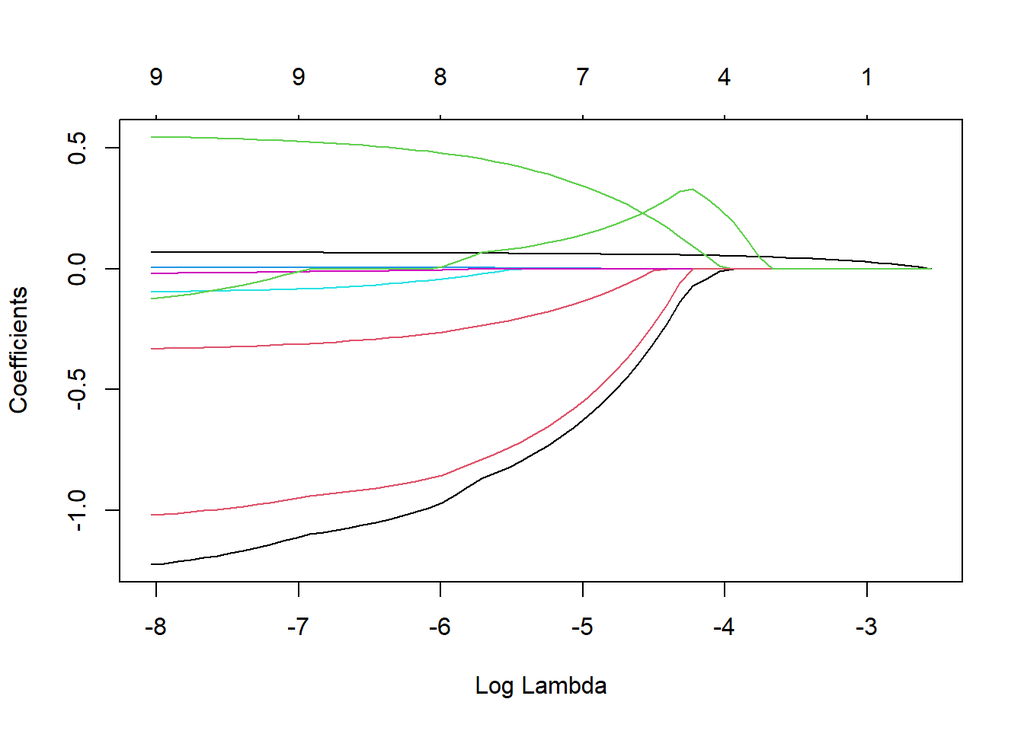

```r
lasso<-glmnet(train.x,train.y,alpha= 1, family='binomial',weights=train.data$weight,lambda=lambdas)
plot(lasso,xvar='lambda')
```

```r
pred<-predict(lasso.fit,test.x,s='lambda.min',type='response')
my.roc<-WeightedROC(pred,test.y,test.data$weight)
WeightedAUC(my.roc)
```

```
## [1] 0.7448869
```

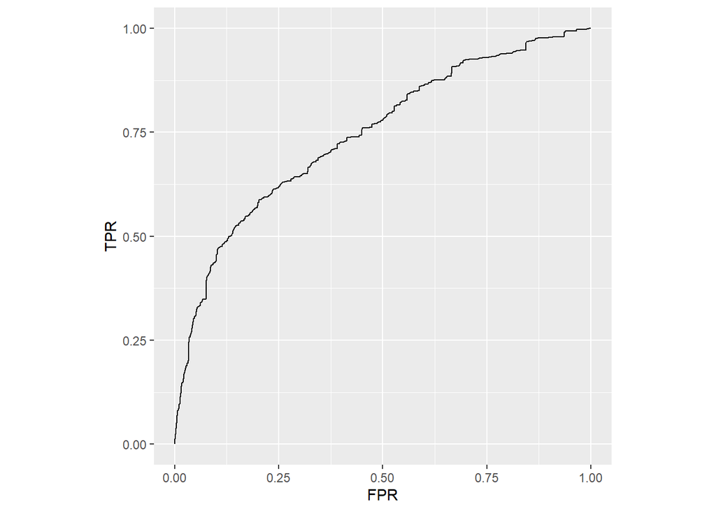

```r
ggplot()+geom_path(aes(FPR,TPR),data=my.roc)+coord_equal()
```

```r
coef(lasso.fit,s='lambda.min')
```

```
## 10 x 1 sparse Matrix of class "dgCMatrix"
##                        s1
## (Intercept)  -3.184390107
## dvcat         0.065609032
## frontal      -0.290652890
## sex           0.506389354
## ageOFocc      0.004935328
## occRole      -0.066657277
## vehage       -0.009750606
## beltedab     -1.049618197
## onlyseatbelt -0.907710186
## onlyairbag    .
```

#### Elastic Net regression

This model is a combination of the Ridge and Lasso regressions, based on a weighted mean of the two regularizations, in order to have easier computation and the advantage of model selection of Lasso regularization.

```r
for (i in c(0,0.1,0.2,0.3,0.4, 0.5,0.6,0.7,0.8,0.9,1)) {
elastic_net<-cv.glmnet(train.x, train.y, weights = train.data$weight, alpha=i,  family="binomial")

print(coef(elastic_net))

pred<-predict(elastic_net, test.x, type="response", s="lambda.min")
myroc<-WeightedROC(pred, test.y, test.data$weight)
print(WeightedAUC(myroc))
}
```

```
## 10 x 1 sparse Matrix of class "dgCMatrix"
##                        s1
## (Intercept)  -2.822077414
## dvcat         0.028639571
## frontal      -0.061991059
## sex           0.130307370
## ageOFocc      0.001691259
## occRole      -0.051535399
## vehage        0.005946877
## beltedab     -0.201659588
## onlyseatbelt -0.148169586
## onlyairbag    0.312487295
## [1] 0.7431653
## 10 x 1 sparse Matrix of class "dgCMatrix"
##                       s1
## (Intercept)  -2.87343582
## dvcat         0.03081403
## frontal       .
## sex           0.04512049
## ageOFocc      .
## occRole       .
## vehage        .
## beltedab     -0.12188509
## onlyseatbelt -0.03382258
## onlyairbag    0.21093785
## [1] 0.7430528
## 10 x 1 sparse Matrix of class "dgCMatrix"
##                       s1
## (Intercept)  -2.92596398
## dvcat         0.03242399
## frontal       .
## sex           .
## ageOFocc      .
## occRole       .
## vehage        .
## beltedab     -0.04831971
## onlyseatbelt  .
## onlyairbag    0.12205927
## [1] 0.7436634
## 10 x 1 sparse Matrix of class "dgCMatrix"
```

[output cut: 88 more lines]

```
## onlyairbag    0.31696568
## [1] 0.7447258
## 10 x 1 sparse Matrix of class "dgCMatrix"
##                       s1
## (Intercept)  -2.84708981
## dvcat         0.02863346
## frontal       .
## sex           .
## ageOFocc      .
## occRole       .
## vehage        .
## beltedab      .
## onlyseatbelt  .
## onlyairbag    .
## [1] 0.744526
```

```r
elastic_net<-cv.glmnet(train.x, train.y, weights = train.data$weight, alpha=0.1,  family="binomial")

print(coef(elastic_net))
```

```
## 10 x 1 sparse Matrix of class "dgCMatrix"
##                        s1
## (Intercept)  -3.020518707
## dvcat         0.037888121
## frontal      -0.005684894
## sex           0.112823756
## ageOFocc      .
## occRole       .
## vehage        .
## beltedab     -0.201055930
## onlyseatbelt -0.113836110
## onlyairbag    0.278828407
```

```r
pred<-predict(elastic_net, test.x, type="response", s="lambda.min")
myroc<-WeightedROC(pred, test.y, test.data$weight)
print(WeightedAUC(myroc))
```

```
## [1] 0.7432493
```

## Discriminant Analysis methods

#### Linear Discriminant Analysis (LDA)

Although we got quite good results with regularized models, we will also try other models, like LDA and QDA. These models have a theoretical problem because our dataset has almost only binary variables, which are not really fit to this model. LDA is more suited for continuous predictors.

```r
lda_model<-lda(severe~dvcat+frontal+sex+ageOFocc+vehage+onlyairbag+onlyseatbelt+beltedab+occRole, data=train.data, weights=train.data$weight)

lda_model.pred<-predict(lda_model, test.data, weights=test.data$weight)
lda_model.post<-lda_model.pred$posterior
lda_model.class<-lda_model.pred$class

mean(lda_model.class!=test.data$severe)*100
```

```
## [1] 28.37082
```

At first we look for the coefficients returned by the model

```r
coef(lda_model)
```

```
##                      LD1
## dvcat         0.06770665
## frontal      -0.35100585
## sex           0.36236311
## ageOFocc      0.01572615
## vehage       -0.01441088
## onlyairbag   -0.22928480
## onlyseatbelt -1.04681659
## beltedab     -1.27082431
## occRole       0.11057116
```

As seen in the majority of the models, the most relevant factors, those with the highest coefficients, are the accident’s speed, the presence of the seatbelt and the activation of the airbag, but only if the injured person was wearing a seatbelt in the accident.

We now test various thresholds to see whether it can be reached a better result

```r
#threshold=0.4
lda_model.pred4<-as.factor(ifelse(lda_model.post[,2]>= 0.4, 1, 0))
mean(lda_model.pred4!=test.data$severe)
```

```
## [1] 0.3013912
```

```r
#threshold=0.5
lda_model.pred5<-as.factor(ifelse(lda_model.post[,2]>= 0.5, 1, 0))
mean(lda_model.pred5!=test.data$severe)
```

```
## [1] 0.2837082
```

```r
#threshold=0.6
lda_model.pred6<-as.factor(ifelse(lda_model.post[,2]>= 0.6, 1, 0))
mean(lda_model.pred6!=test.data$severe)
```

```
## [1] 0.2904694
```

We choose 0.5 as best threshold since it is the one with the smaller error.

```r
conf_mat<-table(test.data$severe, lda_model.pred5)
conf_mat
```

```
##    lda_model.pred5
##        0    1
##   0 4129  713
##   1 1469 1380
```

```r
#True positive rate
TPR<-conf_mat[2,2]/sum(conf_mat[2,])
TPR
```

```
## [1] 0.4843805
```

```r
#True negative rate
TNR<-conf_mat[1,1]/sum(conf_mat[1,])
TNR
```

```
## [1] 0.8527468
```

```r
#Precision
prec<-conf_mat[2,2]/sum(conf_mat[,2])
prec
```

```
## [1] 0.6593407
```

```r
#Recall
rec<-conf_mat[2,2]/sum(conf_mat[2,])
rec
```

```
## [1] 0.4843805
```

```r
#F1 score
F1_lda<-2*(prec*rec)/(prec+rec)
F1_lda
```

```
## [1] 0.5584783
```

```r
#AUC
myroc_lda<-WeightedROC(lda_model.pred$x, test.data$severe, weight=test.data$weight)
WeightedAUC(myroc_lda)
```

```
## [1] 0.7432098
```

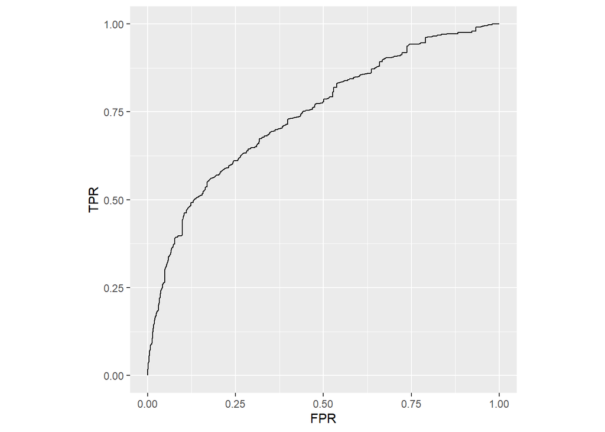

```r
ggplot()+geom_path(aes(FPR,TPR),data=myroc_lda)+coord_equal()
```

The result is similar to the regularized models, which means that although data consist of almost only binary variables they are quite well linearly separated.

#### Quadratic Discriminant Analysis (QDA)

QDA differs from LDA in the fact that all predictors have different variances, but it suffers from the same problem of Linear Discriminant Analysis.

```r
qda_model<-qda(severe~dvcat+frontal+sex+ageOFocc+vehage+onlyairbag+onlyseatbelt+beltedab+occRole, data=train.data, weights=train.data$weight)
qda_model
```

```
## Call:
## qda(severe ~ dvcat + frontal + sex + ageOFocc + vehage + onlyairbag +
##     onlyseatbelt + beltedab + occRole, data = train.data, weights = train.data$weight)
##
## Prior probabilities of groups:
##         0         1
## 0.6254299 0.3745701
##
## Group means:
##      dvcat   frontal       sex ageOFocc   vehage onlyairbag onlyseatbelt
## 0 23.42806 0.6552244 0.4549406 36.05331 6.531311 0.09659393    0.3066347
## 1 33.71520 0.6235190 0.4816351 39.00504 7.242447 0.17639218    0.2513329
##    beltedab   occRole
## 0 0.4833245 0.7899592
## 1 0.3210900 0.7911730
```

```r
qda_model.pred<-predict(qda_model, test.data, weights=test.data$weight)
qda_model.post<-qda_model.pred$posterior
qda_model.class<-qda_model.pred$class
qda_model.x<-qda_model.pred$x

mean(qda_model.class!=test.data$severe)*100
```

```
## [1] 32.53153
```

We look for the best threshold

```r
#threshold=0.4
qda_model.pred4<-as.factor(ifelse(qda_model.post[,2]>= 0.4, 1, 0))
mean(qda_model.pred4!=test.data$severe)
```

```
## [1] 0.3301261
```

```r
#threshold=0.5
qda_model.pred5<-as.factor(ifelse(qda_model.post[,2]>= 0.5, 1, 0))
mean(qda_model.pred5!=test.data$severe)
```

```
## [1] 0.3253153
```

```r
#threshold=0.6
qda_model.pred6<-as.factor(ifelse(qda_model.post[,2]>= 0.6, 1, 0))
mean(qda_model.pred6!=test.data$severe)
```

```
## [1] 0.317514
```

```r
library('ROCR')
conf_mat<-table(test.data$severe, qda_model.pred6)
conf_mat
```

```
##    qda_model.pred6
##        0    1
##   0 3798 1044
##   1 1398 1451
```

```r
#True positive rate
TPR<-conf_mat[2,2]/sum(conf_mat[2,])
TPR
```

```
## [1] 0.5093015
```

```r
#True negative rate
TNR<-conf_mat[1,1]/sum(conf_mat[1,])
TNR
```

```
## [1] 0.7843866
```

```r
#Precision
prec<-conf_mat[2,2]/sum(conf_mat[,2])
prec
```

```
## [1] 0.5815631
```

```r
#Recall
rec<-conf_mat[2,2]/sum(conf_mat[2,])
rec
```

```
## [1] 0.5093015
```

```r
#F1 score
F1_lda<-2*(prec*rec)/(prec+rec)
F1_lda
```

```
## [1] 0.5430389
```

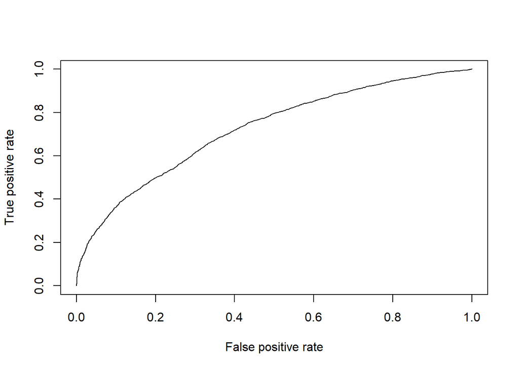

```r
#AUC
prediction(qda_model.pred$posterior[,2], test.y) %>%
  performance(measure = "tpr", x.measure = "fpr") %>%
  plot()
```

We see that in our setting the QDA model gives us worse results than simple LDA. From a general point of view, regularized models proved to be the best solution for this specific problem due to the risk of overfitting, although also the Discriminant Analysis methods turned out to be quite good even if they are generally better performing in multiclass problems. The Elastic Net regression was not excessively better than simple Ridge or Lasso regression since these two already had similar performances. All models give out the same result that the most significative predictor is the “dvcat”, i.e. the speed at which the accidents happen, and as already seen in our previous analysis the airbag becomes effective almost only in presence of the seatbelt, turning out to be quite dangerous if not cohadiuvated.

## Interactions with linear models for the dead factor

In this section we want to understand which interactions are more meaningful to the dead factor. In order to do this we will see which are the coefficients in a model that presents all possible interactions between the predictors

```r
sub_train<-subset(train.data, select = -c(weight, deploy,injSeverity, injSevFactor, yearacc, yearVeh, airbag, seatbelt, severe))
interaction_mod<-glm(dead~.*., data=sub_train, weights=train.data$weight)
summary(interaction_mod)
```

```
##
## Call:
## glm(formula = dead ~ . * ., data = sub_train, weights = train.data$weight)
##
## Deviance Residuals:
##    Min      1Q  Median      3Q     Max
## -7.618  -0.174  -0.029   0.008  50.151
##
## Coefficients: (3 not defined because of singularities)
##                           Estimate Std. Error t value Pr(>|t|)
## (Intercept)             -3.739e-02  1.213e-02  -3.082 0.002058 **
## dvcat                    2.370e-03  2.931e-04   8.086 6.54e-16 ***
## frontal                 -7.149e-04  7.063e-03  -0.101 0.919378
## sex                     -2.215e-04  6.700e-03  -0.033 0.973625
## ageOFocc                -1.835e-05  1.974e-04  -0.093 0.925924
## occRole                 -3.028e-03  8.057e-03  -0.376 0.707077
## vehage                  -4.617e-04  7.010e-04  -0.659 0.510137
## beltedab                 2.581e-02  1.011e-02   2.552 0.010707 *
## onlyseatbelt             3.504e-02  9.038e-03   3.877 0.000106 ***
## onlyairbag              -5.110e-03  1.285e-02  -0.398 0.690751
## dvcat:frontal           -8.409e-04  1.204e-04  -6.985 2.94e-12 ***
## dvcat:sex               -9.216e-05  1.181e-04  -0.780 0.435307
## dvcat:ageOFocc           3.063e-05  3.344e-06   9.158  < 2e-16 ***
## dvcat:occRole           -5.073e-04  1.578e-04  -3.214 0.001311 **
## dvcat:vehage            -2.343e-05  1.430e-05  -1.639 0.101234
## dvcat:beltedab          -1.555e-03  2.124e-04  -7.321 2.56e-13 ***
## dvcat:onlyseatbelt      -1.141e-03  1.719e-04  -6.636 3.31e-11 ***
## dvcat:onlyairbag         2.031e-04  2.693e-04   0.754 0.450773
## frontal:sex             -2.520e-04  2.300e-03  -0.110 0.912776
## frontal:ageOFocc        -3.045e-05  6.752e-05  -0.451 0.651992
## frontal:occRole          1.061e-02  3.042e-03   3.489 0.000486 ***
## frontal:vehage           2.757e-04  3.239e-04   0.851 0.394655
## frontal:beltedab         4.433e-03  5.021e-03   0.883 0.377363
## frontal:onlyseatbelt    -1.092e-03  4.295e-03  -0.254 0.799242
## frontal:onlyairbag      -7.569e-03  6.287e-03  -1.204 0.228646
## sex:ageOFocc            -5.334e-05  6.629e-05  -0.805 0.421061
## sex:occRole             -2.050e-03  3.024e-03  -0.678 0.497717
## sex:vehage              -2.433e-04  3.148e-04  -0.773 0.439655
## sex:beltedab             6.077e-03  4.708e-03   1.291 0.196769
## sex:onlyseatbelt         7.827e-03  4.073e-03   1.922 0.054671 .
```

[output cut: 11 more lines]

```
## vehage:onlyseatbelt     -2.755e-04  4.033e-04  -0.683 0.494564
## vehage:onlyairbag       -8.371e-04  7.638e-04  -1.096 0.273111
## beltedab:onlyseatbelt           NA         NA      NA       NA
## beltedab:onlyairbag             NA         NA      NA       NA
## onlyseatbelt:onlyairbag         NA         NA      NA       NA
## ---
## Signif. codes:  0 '***' 0.001 '**' 0.01 '*' 0.05 '.' 0.1 ' ' 1
##
## (Dispersion parameter for gaussian family taken to be 2.493089)
##
##     Null deviance: 47288  on 18025  degrees of freedom
## Residual deviance: 44833  on 17983  degrees of freedom
## AIC: -16977
##
## Number of Fisher Scoring iterations: 2
```

Let’s try a Lasso model (which performs feature selection too) in order to reduce the number of non-zero interactions.

```r
form<-as.formula(sub_train$dead~.*.)
inter_data<-model.matrix(form, sub_train)[,-1]
inter_target<-sub_train$dead
inter_mod<-cv.glmnet(inter_data, inter_target, weights=train.data$weight, alpha=1, family="binomial")
coef(inter_mod)
```

```
## 46 x 1 sparse Matrix of class "dgCMatrix"
##                                    s1
## (Intercept)             -7.6990302529
## dvcat                    0.0737196809
## frontal                  .
## sex                      .
## ageOFocc                 .
## occRole                  .
## vehage                   .
## beltedab                 .
## onlyseatbelt             .
## onlyairbag               .
## dvcat:frontal            .
## dvcat:sex                .
## dvcat:ageOFocc           0.0004470465
## dvcat:occRole            .
## dvcat:vehage             .
## dvcat:beltedab           .
## dvcat:onlyseatbelt       .
## dvcat:onlyairbag         0.0017071104
## frontal:sex              .
## frontal:ageOFocc         .
## frontal:occRole          .
## frontal:vehage           .
## frontal:beltedab         .
## frontal:onlyseatbelt     .
## frontal:onlyairbag       .
## sex:ageOFocc             .
## sex:occRole              .
## sex:vehage               .
## sex:beltedab             .
## sex:onlyseatbelt         .
## sex:onlyairbag           .
## ageOFocc:occRole         .
## ageOFocc:vehage          .
## ageOFocc:beltedab        .
## ageOFocc:onlyseatbelt    .
## ageOFocc:onlyairbag      .
## occRole:vehage           .
## occRole:beltedab         .
## occRole:onlyseatbelt     .
## occRole:onlyairbag       .
## vehage:beltedab          .
## vehage:onlyseatbelt      .
## vehage:onlyairbag        .
## beltedab:onlyseatbelt    .
## beltedab:onlyairbag      .
## onlyseatbelt:onlyairbag  .
```

There is a major difference with and without regularization, but although that there is a coherence between the two models, with all the coefficients that have small values that have been brought to zero. The most meaningful variable is the dvcat variable by itself, and almost all other interactions have been ignored: in order to partially solve this issue we try to consider more meaningful subsets of variables.

We will try to define a baseline model that can help us a milestone for comparison.

```r
base_mod<-glm(dead~+1, data=sub_train, weights = train.data$weight)
base_mod
```

```
##
## Call:  glm(formula = dead ~ +1, data = sub_train, weights = train.data$weight)
##
## Coefficients:
## (Intercept)
##    0.005574
##
## Degrees of Freedom: 18025 Total (i.e. Null);  18025 Residual
## Null Deviance:       47290
## Residual Deviance: 47290     AIC: -16100
```

In order to have a first estimate let’s perform a first test on the deviance

```r
test_deviance(interaction_mod, base_mod)
```

```
## [1] 0
```

```r
test_deviance(inter_mod, base_mod)
```

```
## numeric(0)
```

We want to see how the variable “dvcat” interacts with the others, in order to understand how much of a change there is in the predictors coefficients based on the speed of the accident

```r
inter_mod_dvcat<-glm(dead~dvcat*., data=sub_train, weights=train.data$weight, family="binomial")
summary(inter_mod_dvcat)
```

```
##
## Call:
## glm(formula = dead ~ dvcat * ., family = "binomial", data = sub_train,
##     weights = train.data$weight)
##
## Deviance Residuals:
##     Min       1Q   Median       3Q      Max
## -45.758   -1.361   -0.561   -0.221  152.043
##
## Coefficients:
##                      Estimate Std. Error  z value Pr(>|z|)
## (Intercept)        -7.505e+00  6.233e-02 -120.410  < 2e-16 ***
## dvcat               1.056e-01  1.420e-03   74.388  < 2e-16 ***
## frontal            -1.697e+00  2.993e-02  -56.696  < 2e-16 ***
## sex                -6.244e-01  3.045e-02  -20.509  < 2e-16 ***
## ageOFocc            5.375e-02  7.146e-04   75.216  < 2e-16 ***
## occRole            -1.084e+00  3.207e-02  -33.799  < 2e-16 ***
## vehage              3.424e-02  3.211e-03   10.662  < 2e-16 ***
## beltedab           -4.304e+00  5.478e-02  -78.581  < 2e-16 ***
## onlyseatbelt       -2.761e+00  3.849e-02  -71.746  < 2e-16 ***
## onlyairbag         -3.124e-01  4.719e-02   -6.621 3.57e-11 ***
## dvcat:frontal       1.508e-02  6.687e-04   22.557  < 2e-16 ***
## dvcat:sex           9.648e-03  6.884e-04   14.016  < 2e-16 ***
## dvcat:ageOFocc     -5.491e-04  1.635e-05  -33.590  < 2e-16 ***
## dvcat:occRole       1.297e-02  7.498e-04   17.304  < 2e-16 ***
## dvcat:vehage       -1.173e-03  7.106e-05  -16.504  < 2e-16 ***
## dvcat:beltedab      6.842e-02  1.166e-03   58.691  < 2e-16 ***
## dvcat:onlyseatbelt  4.243e-02  8.613e-04   49.259  < 2e-16 ***
## dvcat:onlyairbag    8.518e-03  1.095e-03    7.777 7.45e-15 ***
## ---
## Signif. codes:  0 '***' 0.001 '**' 0.01 '*' 0.05 '.' 0.1 ' ' 1
##
## (Dispersion parameter for binomial family taken to be 1)
##
##     Null deviance: 588405  on 18025  degrees of freedom
## Residual deviance: 394780  on 18008  degrees of freedom
## AIC: 394816
##
## Number of Fisher Scoring iterations: 7
```

```r
test_deviance(inter_mod_dvcat,inter_mod)
```

```
## numeric(0)
```

```r
exp(cbind(coef(inter_mod_dvcat), confint.default(inter_mod_dvcat)))
```

```
##                                        2.5 %       97.5 %
## (Intercept)        0.0005504556 0.0004871578 0.0006219779
## dvcat              1.1113739305 1.1082860887 1.1144703755
## frontal            0.1832116743 0.1727720556 0.1942820988
## sex                0.5355859719 0.5045613442 0.5685182517
## ageOFocc           1.0552169280 1.0537401233 1.0566958024
## occRole            0.3382345828 0.3176270860 0.3601790843
## vehage             1.0348335240 1.0283405192 1.0413675260
## beltedab           0.0135097968 0.0121345457 0.0150409100
## onlyseatbelt       0.0632042820 0.0586118149 0.0681565870
## onlyairbag         0.7316699080 0.6670372410 0.8025651664
## dvcat:frontal      1.0151982774 1.0138685933 1.0165297055
## dvcat:sex          1.0096948704 1.0083334964 1.0110580825
## dvcat:ageOFocc     0.9994510105 0.9994189861 0.9994830360
## dvcat:occRole      1.0130589868 1.0115713338 1.0145488276
## dvcat:vehage       0.9988278994 0.9986887996 0.9989670186
## dvcat:beltedab     1.0708180679 1.0683740735 1.0732676532
## dvcat:onlyseatbelt 1.0433393625 1.0415795772 1.0451021210
## dvcat:onlyairbag   1.0085539877 1.0063912170 1.0107214061
```

##### Safety measures interaction

In this section we want to understand how the safety measures and other predictors interact: the first model revolves around whether understanding how the presence of safety measures effects the death rate of a frontal accident.

```r
inter_mod_frontal<-glm(dead~frontal*(occRole+beltedab+onlyairbag+onlyseatbelt), data=sub_train, weights=train.data$weight, family="binomial")
summary(inter_mod_frontal)
```

```
##
## Call:
## glm(formula = dead ~ frontal * (occRole + beltedab + onlyairbag +
##     onlyseatbelt), family = "binomial", data = sub_train, weights = train.data$weight)
##
## Deviance Residuals:
##     Min       1Q   Median       3Q      Max
## -29.177   -1.762   -0.913   -0.450  148.068
##
## Coefficients:
##                      Estimate Std. Error  z value Pr(>|z|)
## (Intercept)          -3.25786    0.01551 -210.086  < 2e-16 ***
## frontal              -1.09817    0.02356  -46.613  < 2e-16 ***
## occRole              -0.79228    0.01398  -56.684  < 2e-16 ***
## beltedab             -1.76514    0.01878  -94.000  < 2e-16 ***
## onlyairbag            0.15658    0.01943    8.059  7.7e-16 ***
## onlyseatbelt         -1.05945    0.01759  -60.235  < 2e-16 ***
## frontal:occRole       1.19115    0.02306   51.664  < 2e-16 ***
## frontal:beltedab     -0.88612    0.02768  -32.015  < 2e-16 ***
## frontal:onlyairbag   -0.67666    0.02635  -25.679  < 2e-16 ***
## frontal:onlyseatbelt -0.95959    0.02508  -38.258  < 2e-16 ***
## ---
## Signif. codes:  0 '***' 0.001 '**' 0.01 '*' 0.05 '.' 0.1 ' ' 1
##
## (Dispersion parameter for binomial family taken to be 1)
##
##     Null deviance: 588405  on 18025  degrees of freedom
## Residual deviance: 540354  on 18016  degrees of freedom
## AIC: 540374
##
## Number of Fisher Scoring iterations: 7
```

```r
exp(cbind(coef(inter_mod_frontal), confint.default(inter_mod_frontal)))
```

```
##                                      2.5 %     97.5 %
## (Intercept)          0.03847061 0.03731894 0.03965783
## frontal              0.33348144 0.31843304 0.34924099
## occRole              0.45281119 0.44057489 0.46538732
## beltedab             0.17116246 0.16497748 0.17757933
## onlyairbag           1.16949959 1.12580202 1.21489326
## onlyseatbelt         0.34664738 0.33490097 0.35880578
## frontal:occRole      3.29085548 3.14545665 3.44297538
## frontal:beltedab     0.41225405 0.39048599 0.43523561
## frontal:onlyairbag   0.50831049 0.48272414 0.53525302
## frontal:onlyseatbelt 0.38305027 0.36467500 0.40235144
```

```r
inter_mod_occRole<-glm(dead~occRole*(onlyairbag+onlyseatbelt+frontal+beltedab), data=sub_train, weights=train.data$weight, family="binomial")
summary(inter_mod_occRole)
```

```
##
## Call:
## glm(formula = dead ~ occRole * (onlyairbag + onlyseatbelt + frontal +
##     beltedab), family = "binomial", data = sub_train, weights = train.data$weight)
##
## Deviance Residuals:
##     Min       1Q   Median       3Q      Max
## -37.148   -1.747   -0.915   -0.465  149.903
##
## Coefficients:
##                      Estimate Std. Error  z value Pr(>|z|)
## (Intercept)          -3.40672    0.01906 -178.695  < 2e-16 ***
## occRole              -0.15493    0.02186   -7.086 1.38e-12 ***
## onlyairbag            0.08245    0.02986    2.761  0.00576 **
## onlyseatbelt         -0.67588    0.02360  -28.640  < 2e-16 ***
## frontal              -1.54187    0.02035  -75.776  < 2e-16 ***
## beltedab             -1.58847    0.02783  -57.078  < 2e-16 ***
## occRole:onlyairbag   -0.42266    0.03310  -12.770  < 2e-16 ***
## occRole:onlyseatbelt -1.19525    0.02757  -43.347  < 2e-16 ***
## occRole:frontal       1.04542    0.02298   45.485  < 2e-16 ***
## occRole:beltedab     -0.83299    0.03163  -26.332  < 2e-16 ***
## ---
## Signif. codes:  0 '***' 0.001 '**' 0.01 '*' 0.05 '.' 0.1 ' ' 1
##
## (Dispersion parameter for binomial family taken to be 1)
##
##     Null deviance: 588405  on 18025  degrees of freedom
## Residual deviance: 540245  on 18016  degrees of freedom
## AIC: 540265
##
## Number of Fisher Scoring iterations: 7
```

```r
exp(cbind(coef(inter_mod_occRole), confint.default(inter_mod_occRole)))
```

```
##                                      2.5 %     97.5 %
## (Intercept)          0.03314968 0.03193387 0.03441177
## occRole              0.85647767 0.82054905 0.89397946
## onlyairbag           1.08594895 1.02421529 1.15140355
## onlyseatbelt         0.50870734 0.48571340 0.53278982
## frontal              0.21398035 0.20561452 0.22268656
## beltedab             0.20423795 0.19339604 0.21568766
## occRole:onlyairbag   0.65529845 0.61413846 0.69921700
## occRole:onlyseatbelt 0.30262835 0.28670722 0.31943360
## occRole:frontal      2.84459949 2.71930118 2.97567121
## occRole:beltedab     0.43474625 0.40860980 0.46255449
```

This analysis gives us an interesting result: the driver risks much less than the passenger. There is a much smaller coefficient for each security measure when we consider only the drivers’ data. The only exception is the frontal predictor: this makes sense too, since frontal accidents happen often when a vehicle enters the opposite lane, thus it is more frequent that this type of accidents happen to the driver who is in the center of the road. This can be seen as a statistical proof of what any of us have learnt when learning to drive, which is that the driver is safer than the passenger in the front row since he is more tense and ready to the dangers one might face while on the road.

```r
inter_mod_sex<-glm(dead~sex*(onlyairbag+onlyseatbelt+frontal+beltedab+occRole), data=sub_train, weights=train.data$weight, family="binomial")
summary(inter_mod_sex)
```

```
##
## Call:
## glm(formula = dead ~ sex * (onlyairbag + onlyseatbelt + frontal +
##     beltedab + occRole), family = "binomial", data = sub_train,
##     weights = train.data$weight)
##
## Deviance Residuals:
##     Min       1Q   Median       3Q      Max
## -29.388   -1.773   -0.912   -0.458  147.620
##
## Coefficients:
##                   Estimate Std. Error  z value Pr(>|z|)
## (Intercept)      -3.458564   0.016905 -204.588  < 2e-16 ***
## sex               0.118765   0.025869    4.591 4.41e-06 ***
## onlyairbag       -0.408206   0.016209  -25.184  < 2e-16 ***
## onlyseatbelt     -1.790434   0.015781 -113.452  < 2e-16 ***
## frontal          -0.468260   0.011992  -39.047  < 2e-16 ***
## beltedab         -2.311356   0.017383 -132.970  < 2e-16 ***
## occRole          -0.005844   0.015712   -0.372     0.71
## sex:onlyairbag    0.672817   0.028066   23.973  < 2e-16 ***
## sex:onlyseatbelt  0.757607   0.026207   28.908  < 2e-16 ***
## sex:frontal      -0.751554   0.019784  -37.988  < 2e-16 ***
## sex:beltedab      0.511148   0.028542   17.908  < 2e-16 ***
## sex:occRole      -0.689950   0.022352  -30.868  < 2e-16 ***
## ---
## Signif. codes:  0 '***' 0.001 '**' 0.01 '*' 0.05 '.' 0.1 ' ' 1
##
## (Dispersion parameter for binomial family taken to be 1)
##
##     Null deviance: 588405  on 18025  degrees of freedom
## Residual deviance: 540564  on 18014  degrees of freedom
## AIC: 540588
##
## Number of Fisher Scoring iterations: 7
```

```r
exp(cbind(coef(inter_mod_sex), confint.default(inter_mod_sex)))
```

```
##                                  2.5 %     97.5 %
## (Intercept)      0.03147494 0.03044916 0.03253527
## sex              1.12610538 1.07043162 1.18467475
## onlyairbag       0.66484203 0.64405247 0.68630267
## onlyseatbelt     0.16688780 0.16180480 0.17213048
## frontal          0.62609102 0.61154668 0.64098126
## beltedab         0.09912674 0.09580644 0.10256210
## occRole          0.99417332 0.96402473 1.02526477
## sex:onlyairbag   1.95975076 1.85485944 2.07057362
## sex:onlyseatbelt 2.13316472 2.02635985 2.24559902
## sex:frontal      0.47163288 0.45369514 0.49027983
## sex:beltedab     1.66720405 1.57649789 1.76312913
## sex:occRole      0.50160122 0.48010103 0.52406425
```

This model gives us the same results that we got considering the interactions with the severity of the injury, which is that women risk more even when security measures activate. This may be due to their smaller physique, that increases the gap with the seatbelt and the airbagand creates a higher risk of damage due to airbag inflation.

## Conclusions

We analyzed the nassCDS dataset of US traffic accidents.

We’ve found that: